# **Used Cars Price Prediction**

## **Problem Definition**

### **The Context:**

- Why is this problem important to solve?
- My answer: We need an accurate model to predict the price of the used cars to help users to make better decisions. This creates profit if the model is precise enough.

### **The objective:**

- What is the intended goal?
- My answer: Build 3 regression models (Linear regression, Decision Tree, Random Forest) and find the best model to predict the price of the used cars

### **The key questions:**

- What are the key questions that need to be answered?
- My answer: Which model is the best for this case?/What insights can we get from EDA?

### **The problem formulation**:

- What is it that we are trying to solve using data science?
- My answer: Compare the different pricing models and find the best one to fit the reality.

### **Data Dictionary**

**S.No.** : Serial Number

**Name** : Name of the car which includes Brand name and Model name

**Location** : The location in which the car is being sold or is available for purchase (Cities)

**Year** : Manufacturing year of the car

**Kilometers_driven** : The total kilometers driven in the car by the previous owner(s) in KM

**Fuel_Type** : The type of fuel used by the car (Petrol, Diesel, Electric, CNG, LPG)

**Transmission** : The type of transmission used by the car (Automatic / Manual)

**Owner** : Type of ownership

**Mileage** : The standard mileage offered by the car company in kmpl or km/kg

**Engine** : The displacement volume of the engine in CC

**Power** : The maximum power of the engine in bhp

**Seats** : The number of seats in the car

**New_Price** : The price of a new car of the same model in INR 100,000

**Price** : The price of the used car in INR 100,000 (**Target Variable**)

### **Loading libraries**

```python
# To ignore warnings
import warnings
warnings.filterwarnings("ignore")

# Import basic data manipulation packages
import numpy as np
import pandas as pd
import seaborn as sns
import matplotlib.pyplot as plt

# Importing libraries for building linear regression model
import statsmodels.api as sm
from statsmodels.stats.outliers_influence import variance_inflation_factor

# Import spliting package
from sklearn.model_selection import train_test_split

# Importing libraries for scaling the data
from sklearn.preprocessing import MinMaxScaler
```

### **Let us load the data**

```python
data = pd.read_csv(r'D:\MIT Applied Data Science\capstone\used_cars.csv')
data.head()
```

|  | S.No. | Name | Location | Year | Kilometers_Driven | Fuel_Type | Transmission | Owner_Type | Mileage | Engine | Power | Seats | New_price | Price |
| --- | --- | --- | --- | --- | --- | --- | --- | --- | --- | --- | --- | --- | --- | --- |
| 0 | 0 | Maruti Wagon R LXI CNG | Mumbai | 2010 | 72000 | CNG | Manual | First | 26.60 | 998.0 | 58.16 | 5.0 | NaN | 1.75 |
| 1 | 1 | Hyundai Creta 1.6 CRDi SX Option | Pune | 2015 | 41000 | Diesel | Manual | First | 19.67 | 1582.0 | 126.20 | 5.0 | NaN | 12.50 |
| 2 | 2 | Honda Jazz V | Chennai | 2011 | 46000 | Petrol | Manual | First | 18.20 | 1199.0 | 88.70 | 5.0 | 8.61 | 4.50 |
| 3 | 3 | Maruti Ertiga VDI | Chennai | 2012 | 87000 | Diesel | Manual | First | 20.77 | 1248.0 | 88.76 | 7.0 | NaN | 6.00 |
| 4 | 4 | Audi A4 New 2.0 TDI Multitronic | Coimbatore | 2013 | 40670 | Diesel | Automatic | Second | 15.20 | 1968.0 | 140.80 | 5.0 | NaN | 17.74 |

## Data Overview

- Observations
- Sanity checks

```python
# Check data shape
data.shape
```

```
(7253, 14)
```

This data set has 7253 rows and 14 columns

```python
data.info()
```

```
<class 'pandas.core.frame.DataFrame'>
RangeIndex: 7253 entries, 0 to 7252
Data columns (total 14 columns):
 #   Column             Non-Null Count  Dtype
---  ------             --------------  -----
 0   S.No.              7253 non-null   int64
 1   Name               7253 non-null   object
 2   Location           7253 non-null   object
 3   Year               7253 non-null   int64
 4   Kilometers_Driven  7253 non-null   int64
 5   Fuel_Type          7253 non-null   object
 6   Transmission       7253 non-null   object
 7   Owner_Type         7253 non-null   object
 8   Mileage            7251 non-null   float64
 9   Engine             7207 non-null   float64
 10  Power              7078 non-null   float64
 11  Seats              7200 non-null   float64
 12  New_price          1006 non-null   float64
 13  Price              6019 non-null   float64
dtypes: float64(6), int64(3), object(5)
memory usage: 793.4+ KB
```

integer data: S.No., Year, Kilometers_Driven object data: Name, Location, Fuel_Type , Transmission, Owner_Type float data: Mileage, Engine, Power, Seats, New_price, Price

```python
# Check missing data
data.isnull().sum()
```

```
S.No.                   0
Name                    0
Location                0
Year                    0
Kilometers_Driven       0
Fuel_Type               0
Transmission            0
Owner_Type              0
Mileage                 2
Engine                 46
Power                 175
Seats                  53
New_price            6247
Price                1234
dtype: int64
```

```python
# Check duplicated data

data.duplicated().sum()
```

```
0
```

Mileage, Engine, Power, Seats, New_Price,Price have missing data

```python
# Show missing data percentage

((data.isnull().sum()/data.shape[0])*100).astype(str) +'%'
```

```
S.No.                                0.0%
Name                                 0.0%
Location                             0.0%
Year                                 0.0%
Kilometers_Driven                    0.0%
Fuel_Type                            0.0%
Transmission                         0.0%
Owner_Type                           0.0%
Mileage              0.02757479663587481%
Engine                0.6342203226251206%
Power                 2.4127947056390457%
Seats                 0.7307321108506825%
New_price              86.12987729215497%
Price                  17.01364952433476%
dtype: object
```

## **Exploratory Data Analysis**

- EDA is an important part of any project involving data.
- It is important to investigate and understand the data better before building a model with it.
- A few questions have been mentioned below which will help you approach the analysis in the right manner and generate insights from the data.
- A thorough analysis of the data, in addition to the questions mentioned below, should be done.

**Questions:**

1. What is the summary statistics of the data? Explore summary statistics for numerical variables and the categorical variables
2. Find out number of unique observations in each category of categorical columns? Write your findings/observations/insights
3. Check the extreme values in different columns of the given data and write down the observtions? Remove the data where the values are un-realistic

```python
# Get the summary statistics of the data

data.describe(include='all').T
```

|  | count | unique | top | freq | mean | std | min | 25% | 50% | 75% | max |
| --- | --- | --- | --- | --- | --- | --- | --- | --- | --- | --- | --- |
| S.No. | 7253 | NaN | NaN | NaN | 3626 | 2093.91 | 0 | 1813 | 3626 | 5439 | 7252 |
| Name | 7253 | 2041 | Mahindra XUV500 W8 2WD | 55 | NaN | NaN | NaN | NaN | NaN | NaN | NaN |
| Location | 7253 | 11 | Mumbai | 949 | NaN | NaN | NaN | NaN | NaN | NaN | NaN |
| Year | 7253 | NaN | NaN | NaN | 2013.37 | 3.25442 | 1996 | 2011 | 2014 | 2016 | 2019 |
| Kilometers_Driven | 7253 | NaN | NaN | NaN | 58699.1 | 84427.7 | 171 | 34000 | 53416 | 73000 | 6.5e+06 |
| Fuel_Type | 7253 | 5 | Diesel | 3852 | NaN | NaN | NaN | NaN | NaN | NaN | NaN |
| Transmission | 7253 | 2 | Manual | 5204 | NaN | NaN | NaN | NaN | NaN | NaN | NaN |
| Owner_Type | 7253 | 4 | First | 5952 | NaN | NaN | NaN | NaN | NaN | NaN | NaN |
| Mileage | 7251 | NaN | NaN | NaN | 18.1416 | 4.5622 | 0 | 15.17 | 18.16 | 21.1 | 33.54 |
| Engine | 7207 | NaN | NaN | NaN | 1616.57 | 595.285 | 72 | 1198 | 1493 | 1968 | 5998 |
| Power | 7078 | NaN | NaN | NaN | 112.765 | 53.4936 | 34.2 | 75 | 94 | 138.1 | 616 |
| Seats | 7200 | NaN | NaN | NaN | 5.28042 | 0.809277 | 2 | 5 | 5 | 5 | 10 |
| New_price | 1006 | NaN | NaN | NaN | 22.7797 | 27.7593 | 3.91 | 7.885 | 11.57 | 26.0425 | 375 |
| Price | 6019 | NaN | NaN | NaN | 9.47947 | 11.1879 | 0.44 | 3.5 | 5.64 | 9.95 | 160 |

```python
# Find out number of unique observations in each category of categorical columns

data[['S.No.','Location','Fuel_Type','Transmission','Owner_Type']].nunique()
```

```
S.No.           7253
Location          11
Fuel_Type          5
Transmission       2
Owner_Type         4
dtype: int64
```

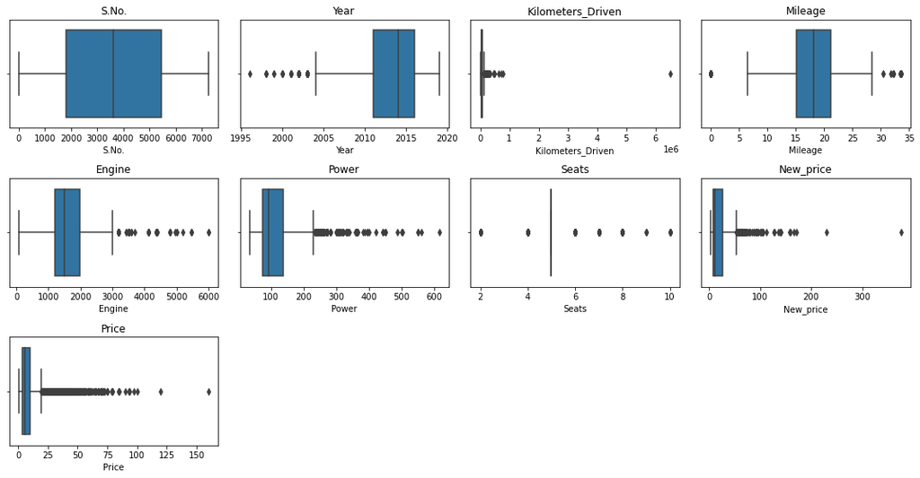

```python
# Check the extreme values in different columns of the given data
# Outlier detection

col = data.select_dtypes(include=np.number).columns.tolist()

plt.figure(figsize = (15,10))

for i, value in enumerate(col):
    plt.subplot(4,4,i+1)
    sns.boxplot(x=data[value])
    plt.tight_layout()
    plt.title(value)

plt.show()
```

```python
# Check the extreme unrealistic data

data['Kilometers_Driven'].max()
```

```
6500000
```

```python
# Kilometers Per Litre is not possible to be 0
data['Mileage'].min()
```

```
0.0
```

```python
# Remove the data where the values are un-realistic

# Remove a data point that says the car has been driven for 650000 km
# Remove a data point that says the car KMPL is 0

data=data[data['Kilometers_Driven']!=data['Kilometers_Driven'].max()]
data=data[data['Mileage']!=data['Mileage'].min()]
```

```python
# Verify the extreme outliers have been removed

print(data['Kilometers_Driven'].max())
print(data['Mileage'].min())
```

```
775000
6.4
```

## **Univariate Analysis**

**Questions:**

1. Do univariate analysis for numerical and categorical variables?
2. Check the distribution of the different variables? is the distributions skewed?
3. Do we need to do log_transformation, if so for what variables we need to do?
4. Perfoem the log_transformation(if needed) and write down your observations?

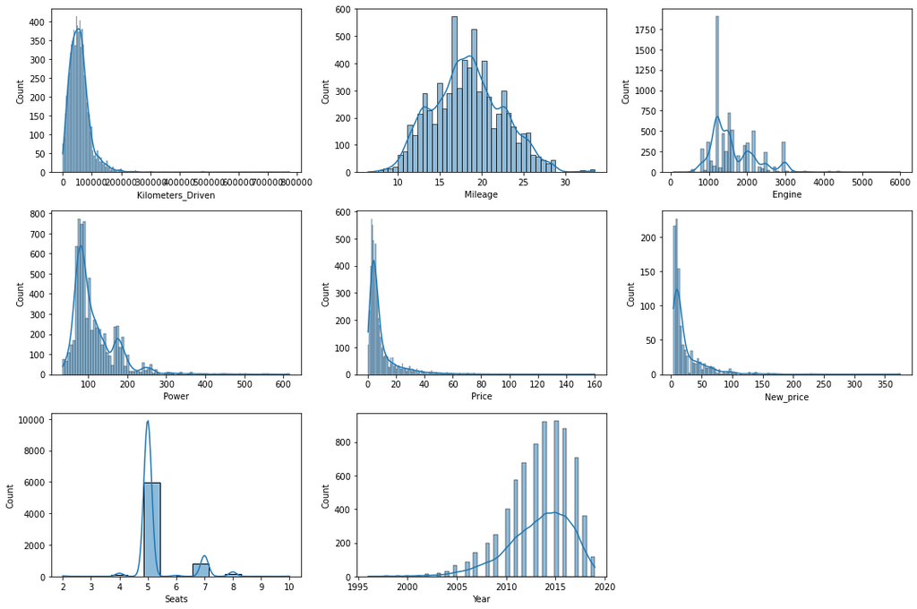

```python
# Do univariate analysis for numerical and categorical variables?

# Create boxplot for numerical variables


numerical_variable_list = ['Kilometers_Driven', 'Mileage', 'Engine',
                          'Power', 'Price', 'New_price','Seats', 'Year']

plt.figure(figsize = (15, 10))

for i, value in enumerate(numerical_variable_list):
    plt.subplot(3, 3, i+1)
    sns.histplot(data = data, x=data[value], kde = True)
    plt.tight_layout()

plt.show()
```

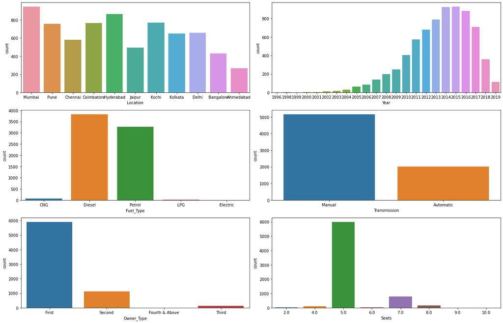

```python
# Create countplot for categorical variables
# Consider year as a categorical variable
# Consider seats as a categorical variable

categorical_variable_list = ['Location','Year', 'Fuel_Type', 'Transmission',
                            'Owner_Type', 'Seats']

plt.figure(figsize = (18, 15))

for i, value in enumerate(categorical_variable_list):
    plt.subplot(4, 2, i+1)
    sns.countplot(x=data[value])
    plt.tight_layout()

plt.show()
```

```python
# Check the sknewness level

from scipy.stats import skew

skewness = skew(data['Kilometers_Driven'])

# Need to drop some missing values to calculate
# Mileage
skewness2 = skew(data['Mileage'].dropna())

# Engine
skewness3 = skew(data['Engine'].dropna())

# Power
skewness4 = skew(data['Power'].dropna())

# Price
skewness5 = skew(data['Price'].dropna())

# New_price
skewness6 = skew(data['New_price'].dropna())

print("Kilometers_Driven sknewness is:", skewness)
print("Mileage sknewness is", skewness2)
print("Engine skewness is:", skewness3)
print("Power skewness is:", skewness4)
print("Price skewness is", skewness5)
print("New_price skewness is", skewness6)
```

```
Kilometers_Driven sknewness is: 3.873391022090457
Mileage sknewness is 0.2048979890021952
Engine skewness is: 1.4218440635406084
Power skewness is: 1.973194396322959
Price skewness is 3.381045788466748
New_price skewness is 4.145784843966587
```

Observation:

Log transformation is commonly used when dealing with positively skewed data

When the skewness value is significantly positive (e.g., greater than 1 or 2), indicating a highly right-skewed distribution, log transformation can help reduce the skewness and make the data more normally distributed.

In these data columns listed above, only "Kilometers_Driven" does not have missing values. Even though the most variables show the high positive skewness, it is wise to wait after missing value treatment.

```python
# Perform log transformation on Kilometer_Driven

data['log_Kilometers_Driven'] = np.log(data['Kilometers_Driven'])
```

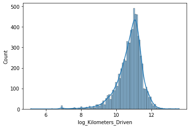

```python
# Check the distribution of the log variable

sns.histplot(data=data, x=data['log_Kilometers_Driven'], kde = True)
```

## **Bivariate Analysis**

**Questions:**

1. Plot a scatter plot for the log transformed values(if log_transformation done in previous steps)?
2. What can we infer form the correlation heatmap? Is there correlation between the dependent and independent variables?
3. Plot a box plot for target variable and categorical variable 'Location' and write your observations?

```python
# Remove S.No. since it is not valueable

data = data.drop('S.No.', axis=1)
```

```python
# Get the coorelation table

data.corr()
```

|  | Year | Kilometers_Driven | Mileage | Engine | Power | Seats | New_price | Price | log_Kilometers_Driven |
| --- | --- | --- | --- | --- | --- | --- | --- | --- | --- |
| Year | 1.000000 | -0.447032 | 0.301159 | -0.063164 | 0.011221 | 0.008538 | -0.063885 | 0.302162 | -0.501243 |
| Kilometers_Driven | -0.447032 | 1.000000 | -0.143640 | 0.163194 | 0.004332 | 0.212703 | -0.004115 | -0.165310 | 0.821805 |
| Mileage | 0.301159 | -0.143640 | 1.000000 | -0.645516 | -0.550847 | -0.350876 | -0.376454 | -0.333494 | -0.136299 |
| Engine | -0.063164 | 0.163194 | -0.645516 | 1.000000 | 0.860136 | 0.406140 | 0.735577 | 0.657597 | 0.156076 |
| Power | 0.011221 | 0.004332 | -0.550847 | 0.860136 | 1.000000 | 0.097175 | 0.877252 | 0.774490 | 0.019286 |
| Seats | 0.008538 | 0.212703 | -0.350876 | 0.406140 | 0.097175 | 1.000000 | -0.018028 | 0.055929 | 0.190796 |
| New_price | -0.063885 | -0.004115 | -0.376454 | 0.735577 | 0.877252 | -0.018028 | 1.000000 | 0.871520 | 0.030371 |
| Price | 0.302162 | -0.165310 | -0.333494 | 0.657597 | 0.774490 | 0.055929 | 0.871520 | 1.000000 | -0.188393 |
| log_Kilometers_Driven | -0.501243 | 0.821805 | -0.136299 | 0.156076 | 0.019286 | 0.190796 | 0.030371 | -0.188393 | 1.000000 |

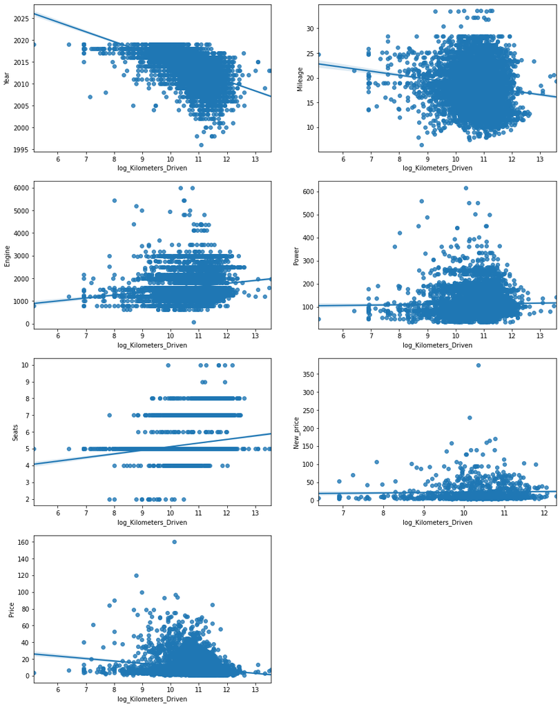

```python
# Plot the scatter plot for the log transformed value

all_variable_list = ['Year','Mileage','Engine','Power','Seats','New_price','Price']

plt.figure(figsize=(15,20))
for i,value in enumerate(all_variable_list):
    plt.subplot(4, 2, i+1)
    sns.regplot(x='log_Kilometers_Driven', y=value, data=data)
plt.show()
```

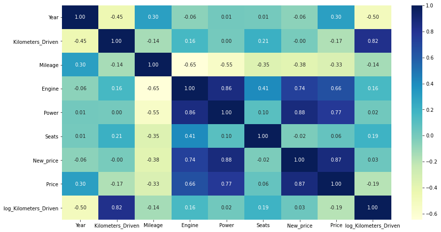

```python
# Plot heatmap

plt.figure(figsize=(15,8))
sns.heatmap(data.corr(), annot=True, fmt='0.2f',cmap = 'YlGnBu')
```

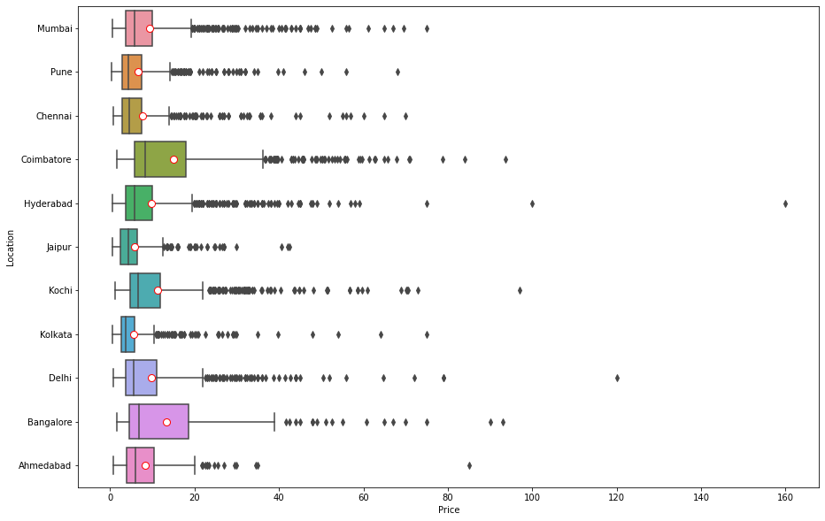

```python
# Boxplot of price by different locations
plt.figure(figsize=(15,10))
sns.boxplot(data=data, x="Price", y="Location", showmeans=True,
           meanprops={'marker':'o',
                       'markerfacecolor':'white',
                       'markeredgecolor':'red',
                       'markersize':'8'})
```

Obversation:

Used cars sold in Coimbatore has the highest average price

Used cars sold in Kolkata has the lowest average price

### **Feature Engineering**

**Think about it:** The `Name` column in the current format might not be very useful in our analysis. Since the name contains both the brand name and the model name of the vehicle, the column would have too many unique values to be useful in prediction. Can we extract that information from that column?

- **Hint:** With 2041 unique names, car names are not going to be great predictors of the price in our current data. But we can process this column to extract important information for example brand name.

```python
# Extract the brand name

data['Make'] = data['Name'].str.split().str[0]
```

```python
# The age of the car might be a factor of price.

data["Car_Age"] = 2023 - data['Year']
```

### **Missing value treatment**

This is an overview of missing value precentage.

Mileage 0.028% Engine 0.63% Power 2.4% Seats 0.73% New_price 86.13% Price 17.0%

Variable "Mileage", "Engine","Seats" missing values are less than 1%, and deleting these missing data might not have significant impact on the dataset.

```python
# Drop data columns mileage, engine, seats
data = data.dropna(subset=['Mileage','Engine','Seats'])
```

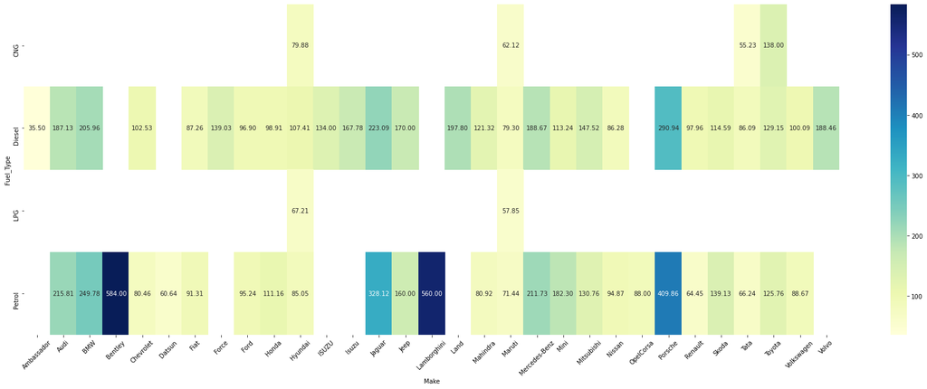

```python
# Find out some relationship of the variable (missing)- Power
# with other variables in the dataset to impute those missing values.
# Imputing missing values for "Power"

fig = plt.figure(figsize = (30, 10))

sns.heatmap(data.pivot_table(index = 'Fuel_Type', columns = 'Make', values = 'Power'), annot = True,
           cmap = 'YlGnBu',fmt='0.2f');

plt.xticks(rotation = 45);
```

Obversation: Based on different combinations of Fuel_Type and Make, the average range of value for the column Power lies between the minimum value of 35.5 and the maximum value of 584.

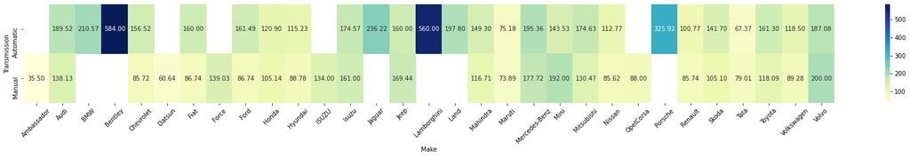

```python
fig = plt.figure(figsize = (30, 3))

sns.heatmap(data.pivot_table(index = 'Transmission', columns = 'Make', values = 'Power'), annot = True,
           cmap = 'YlGnBu', fmt='0.2f');

plt.xticks(rotation = 45);
```

Obversation: Based on different combinations of Transmission and Make, the average range of value for the column Power lies between the minimum value of 35.5 and the maximum value of 584.

```python
# Set the mean and standard deviation

mean=(35.5+584)/2
std = (584-35.5)/6

# Generate random values from normal distribution

random_values = np.random.normal(mean, std, size = data['Power'].isna().sum())

# Fill the missing value

data.loc[data['Power'].isna(), 'Power'] = random_values
```

"New_price" has too much missing data, it might be better to remove the entire column.

"Price" is a target variable. It is not a good idea to do missing value treatment

```python
# Drop new price as well since it has too much missing value
data = data.drop('New_price', axis = 1)
```

```python
# Perform log transformation on price

data['price_log'] = np.log(data['Price'])
data.dropna(subset=['price_log'], inplace = True)
```

```python
# View the data columns
data.head(1)
```

|  | Name | Location | Year | Kilometers_Driven | Fuel_Type | Transmission | Owner_Type | Mileage | Engine | Power | Seats | Price | log_Kilometers_Driven | Make | Car_Age | price_log |
| --- | --- | --- | --- | --- | --- | --- | --- | --- | --- | --- | --- | --- | --- | --- | --- | --- |
| 0 | Maruti Wagon R LXI CNG | Mumbai | 2010 | 72000 | CNG | Manual | First | 26.6 | 998.0 | 58.16 | 5.0 | 1.75 | 11.184421 | Maruti | 13 | 0.559616 |

## **Important Insights from EDA and Data Preprocessing**

What are the the most important observations and insights from the data based on the EDA and Data Preprocessing performed?

Observation:

Dependent variable "price" has strong correlation with variables "power" and "engine"

In Feature Engineering, Car make and car age were added. They can play an important role in the model

Variable "power" missing data was filled with normal distribution based on the heatmap observation.

## **Building Various Models**

1. What we want to predict is the "Price". We will use the normalized version 'price_log' for modeling.
2. Before we proceed to the model, we'll have to encode categorical features. We will drop categorical features like Name.
3. We'll split the data into train and test, to be able to evaluate the model that we build on the train data.
4. Build Regression models using train data.
5. Evaluate the model performance.

### **Split the Data**

Step1: Seperating the indepdent variables (X) and the dependent variable (y).

Step2: Encode the categorical variables in X using pd.dummies.

Step3: Split the data into train and test using train_test_split.

**Question:**

1. Why we should drop 'Name','Price','price_log','Kilometers_Driven' from X before splitting?

Step1: Seperating the indepdent variables (X) and the dependent variable (y).

```python
# Drop dependent variables and complex useless variable-"Name"

X = data.drop(['Name','Price','price_log', 'Kilometers_Driven'], axis=1)

# Only extract dependent variable
y = data['price_log']
```

Q: Why we should drop 'Name','Price','price_log','Kilometers_Driven' from X before splitting?

A: Name is a complex variable and not useful since we have extract the car make information

"Price" and "price_log" are dependent variables

Kilometer_Driven can be removed since it has a log transformed column

Step2: Encode the categorical variables in X using pd.dummies.

```python
X = pd.get_dummies(X, columns = ['Location','Fuel_Type',
                                'Transmission','Owner_Type','Make'])
```

```python
X.head(1)
```

|  | Year | Mileage | Engine | Power | Seats | log_Kilometers_Driven | Car_Age | Location_Ahmedabad | Location_Bangalore | Location_Chennai | ... | Make_Mini | Make_Mitsubishi | Make_Nissan | Make_Porsche | Make_Renault | Make_Skoda | Make_Tata | Make_Toyota | Make_Volkswagen | Make_Volvo |
| --- | --- | --- | --- | --- | --- | --- | --- | --- | --- | --- | --- | --- | --- | --- | --- | --- | --- | --- | --- | --- | --- |
| 0 | 2010 | 26.6 | 998.0 | 58.16 | 5.0 | 11.184421 | 13 | 0 | 0 | 0 | ... | 0 | 0 | 0 | 0 | 0 | 0 | 0 | 0 | 0 | 0 |

1 rows × 58 columns

Step3: Split the data into train and test using train_test_split.

```python
# Split the data into train and test using train_test_split into 70:30 ratio

X_train, X_test, y_train, y_test = train_test_split(
    X, y, test_size = 0.30, random_state = 42)
```

```python
X_train.shape
```

```
(4142, 58)
```

```python
X_test.shape
```

```
(1776, 58)
```

For Regression Problems, some of the algorithms used are :

**1) Linear Regression**  
**2) Ridge / Lasso Regression**  
**3) Decision Trees**  
**4) Random Forest**

# Linear Regression

```python
# Scale the numerical variables to prevent bias

scaler = MinMaxScaler()

# Applying fit_transform on the training features data
X_train_scaled = scaler.fit_transform(X_train)

X_train_scaled = pd.DataFrame(X_train_scaled,
                              index = X_train.index,
                              columns = X_train.columns)

X_train_scaled.head(2)
```

|  | Year | Mileage | Engine | Power | Seats | log_Kilometers_Driven | Car_Age | Location_Ahmedabad | Location_Bangalore | Location_Chennai | ... | Make_Mini | Make_Mitsubishi | Make_Nissan | Make_Porsche | Make_Renault | Make_Skoda | Make_Tata | Make_Toyota | Make_Volkswagen | Make_Volvo |
| --- | --- | --- | --- | --- | --- | --- | --- | --- | --- | --- | --- | --- | --- | --- | --- | --- | --- | --- | --- | --- | --- |
| 681 | 0.904762 | 0.361091 | 0.106997 | 0.075694 | 0.375 | 0.634663 | 0.095238 | 0.0 | 0.0 | 0.0 | ... | 0.0 | 0.0 | 0.0 | 0.0 | 0.0 | 0.0 | 0.0 | 0.0 | 1.0 | 0.0 |
| 223 | 0.714286 | 0.539057 | 0.155750 | 0.058577 | 0.375 | 0.731114 | 0.285714 | 0.0 | 0.0 | 0.0 | ... | 0.0 | 0.0 | 0.0 | 0.0 | 0.0 | 0.0 | 0.0 | 0.0 | 0.0 | 0.0 |

2 rows × 58 columns

```python
# Add constant

X_train_scaled = sm.add_constant(X_train_scaled)
```

```python
# Check for Multicollinearity

from statsmodels.stats.outliers_influence import variance_inflation_factor

# Function to check VIF
def checking_vif(train):
    vif = pd.DataFrame()
    vif["feature"] = train.columns
    vif["VIF"] = [
        variance_inflation_factor(train.values, i) for i in range(len(train.columns))
    ]
    return vif

print(checking_vif(X_train_scaled))
```

```
                      feature           VIF
0                       const  0.000000e+00
1                        Year           inf
2                     Mileage  3.934459e+00
3                      Engine  6.719023e+00
4                       Power  3.662358e+00
5                       Seats  2.538049e+00
6       log_Kilometers_Driven  1.793973e+00
7                     Car_Age           inf
8          Location_Ahmedabad  2.302642e+07
9          Location_Bangalore  2.413350e+06
10           Location_Chennai  8.755672e+06
11        Location_Coimbatore  1.882776e+07
12             Location_Delhi  2.522370e+05
13         Location_Hyderabad  5.558064e+06
```

[output cut: 45 more lines]

Observation:

Features having a VIF score > 5 will be dropped/treated till all the features have a VIF score < 5

VIF for dummy variables can be ignored which is expected that they would have a high VIF

```python
# Drop Engine from X_trian_scaled

X_train_scaled = X_train_scaled.drop('Engine', axis =1)
```

```python
# Run the VIF check function again

print(checking_vif(X_train_scaled))
```

```
                      feature           VIF
0                       const  0.000000e+00
1                        Year           inf
2                     Mileage  3.231993e+00
3                       Power  2.743613e+00
4                       Seats  2.429111e+00
5       log_Kilometers_Driven  1.793065e+00
6                     Car_Age           inf
7          Location_Ahmedabad  1.205928e+07
8          Location_Bangalore  1.929879e+06
9            Location_Chennai  3.079273e+06
10        Location_Coimbatore  1.603787e+07
11             Location_Delhi  5.817155e+05
12         Location_Hyderabad  4.194704e+06
13            Location_Jaipur  3.166232e+06
```

[output cut: 44 more lines]

```python
# Build the model

model1 = sm.OLS(y_train, X_train_scaled).fit()
print(model1.summary())
```

```
                            OLS Regression Results
==============================================================================
Dep. Variable:              price_log   R-squared:                       0.910
Model:                            OLS   Adj. R-squared:                  0.909
Method:                 Least Squares   F-statistic:                     812.2
Date:                Fri, 09 Jun 2023   Prob (F-statistic):               0.00
Time:                        00:29:15   Log-Likelihood:                -318.30
No. Observations:                4142   AIC:                             740.6
Df Residuals:                    4090   BIC:                             1070.
Df Model:                          51
Covariance Type:            nonrobust
=============================================================================================
                                coef    std err          t      P>|t|      [0.025      0.975]
---------------------------------------------------------------------------------------------
const                      -4.98e+11   4.22e+11     -1.180      0.238   -1.33e+12     3.3e+11
Year                       1.147e+12   9.72e+11      1.180      0.238   -7.59e+11    3.05e+12
Mileage                      -1.0205      0.048    -21.232      0.000      -1.115      -0.926
Power                         1.6759      0.062     27.044      0.000       1.554       1.797
Seats                         0.4689      0.064      7.378      0.000       0.344       0.594
log_Kilometers_Driven        -0.3817      0.054     -7.062      0.000      -0.488      -0.276
Car_Age                    1.147e+12   9.72e+11      1.180      0.238   -7.59e+11    3.05e+12
Location_Ahmedabad        -4.564e+10   3.87e+10     -1.180      0.238   -1.22e+11    3.02e+10
Location_Bangalore        -4.564e+10   3.87e+10     -1.180      0.238   -1.22e+11    3.02e+10
Location_Chennai          -4.564e+10   3.87e+10     -1.180      0.238   -1.22e+11    3.02e+10
Location_Coimbatore       -4.564e+10   3.87e+10     -1.180      0.238   -1.22e+11    3.02e+10
Location_Delhi            -4.564e+10   3.87e+10     -1.180      0.238   -1.22e+11    3.02e+10
Location_Hyderabad        -4.564e+10   3.87e+10     -1.180      0.238   -1.22e+11    3.02e+10
Location_Jaipur           -4.564e+10   3.87e+10     -1.180      0.238   -1.22e+11    3.02e+10
Location_Kochi            -4.564e+10   3.87e+10     -1.180      0.238   -1.22e+11    3.02e+10
Location_Kolkata          -4.564e+10   3.87e+10     -1.180      0.238   -1.22e+11    3.02e+10
Location_Mumbai           -4.564e+10   3.87e+10     -1.180      0.238   -1.22e+11    3.02e+10
Location_Pune             -4.564e+10   3.87e+10     -1.180      0.238   -1.22e+11    3.02e+10
Fuel_Type_CNG              -1.58e+11   1.34e+11     -1.180      0.238   -4.21e+11    1.05e+11
Fuel_Type_Diesel           -1.58e+11   1.34e+11     -1.180      0.238   -4.21e+11    1.05e+11
Fuel_Type_LPG              -1.58e+11   1.34e+11     -1.180      0.238   -4.21e+11    1.05e+11
Fuel_Type_Petrol           -1.58e+11   1.34e+11     -1.180      0.238   -4.21e+11    1.05e+11
Transmission_Automatic     -2.77e+11   2.35e+11     -1.180      0.238   -7.37e+11    1.83e+11
Transmission_Manual        -2.77e+11   2.35e+11     -1.180      0.238   -7.37e+11    1.83e+11
Owner_Type_First          -1.483e+11   1.26e+11     -1.180      0.238   -3.95e+11    9.82e+10
Owner_Type_Fourth & Above -1.483e+11   1.26e+11     -1.180      0.238   -3.95e+11    9.82e+10
```

[output cut: 28 more lines]

```
Make_Tata                 -1.968e+10   1.67e+10     -1.180      0.238   -5.24e+10     1.3e+10
Make_Toyota               -1.968e+10   1.67e+10     -1.180      0.238   -5.24e+10     1.3e+10
Make_Volkswagen           -1.968e+10   1.67e+10     -1.180      0.238   -5.24e+10     1.3e+10
Make_Volvo                -1.968e+10   1.67e+10     -1.180      0.238   -5.24e+10     1.3e+10
==============================================================================
Omnibus:                      586.938   Durbin-Watson:                   1.953
Prob(Omnibus):                  0.000   Jarque-Bera (JB):             2200.560
Skew:                          -0.674   Prob(JB):                         0.00
Kurtosis:                       6.306   Cond. No.                     1.38e+16
==============================================================================

Notes:
[1] Standard Errors assume that the covariance matrix of the errors is correctly specified.
[2] The smallest eigenvalue is 9.58e-29. This might indicate that there are
strong multicollinearity problems or that the design matrix is singular.
```

```python
# "year", "car-age" shows a higher p-value (>0.05)
# These two variables can be dropped

X_train_scaled= X_train_scaled.drop(['Year','Car_Age'], axis =1)

#Check VIF

print(checking_vif(X_train_scaled))
```

```
                      feature       VIF
0                       const  0.000000
1                     Mileage  2.943729
2                       Power  2.739333
3                       Seats  2.354928
4       log_Kilometers_Driven  1.365037
5          Location_Ahmedabad       inf
6          Location_Bangalore       inf
7            Location_Chennai       inf
8         Location_Coimbatore       inf
9              Location_Delhi       inf
10         Location_Hyderabad       inf
11            Location_Jaipur       inf
12             Location_Kochi       inf
13           Location_Kolkata       inf
```

[output cut: 42 more lines]

Observation:

Numerical VIF are all lower than 5. We can move forward to rebuild the model

```python
model2 = sm.OLS(y_train, X_train_scaled).fit()
print(model2.summary())
```

```
                            OLS Regression Results
==============================================================================
Dep. Variable:              price_log   R-squared:                       0.804
Model:                            OLS   Adj. R-squared:                  0.802
Method:                 Least Squares   F-statistic:                     336.5
Date:                Fri, 09 Jun 2023   Prob (F-statistic):               0.00
Time:                        00:29:15   Log-Likelihood:                -1929.2
No. Observations:                4142   AIC:                             3960.
Df Residuals:                    4091   BIC:                             4283.
Df Model:                          50
Covariance Type:            nonrobust
=============================================================================================
                                coef    std err          t      P>|t|      [0.025      0.975]
---------------------------------------------------------------------------------------------
const                         1.0782      0.047     22.839      0.000       0.986       1.171
Mileage                      -0.0247      0.068     -0.366      0.715      -0.157       0.108
Power                         1.8316      0.091     20.050      0.000       1.652       2.011
Seats                         1.2365      0.092     13.397      0.000       1.056       1.417
log_Kilometers_Driven        -2.1943      0.069    -31.584      0.000      -2.330      -2.058
Location_Ahmedabad            0.1158      0.029      3.960      0.000       0.058       0.173
Location_Bangalore            0.2701      0.024     11.054      0.000       0.222       0.318
Location_Chennai              0.0746      0.021      3.560      0.000       0.034       0.116
Location_Coimbatore           0.3778      0.019     20.029      0.000       0.341       0.415
Location_Delhi                0.0461      0.020      2.313      0.021       0.007       0.085
Location_Hyderabad            0.1312      0.018      7.427      0.000       0.097       0.166
Location_Jaipur               0.0138      0.022      0.619      0.536      -0.030       0.057
Location_Kochi                0.2624      0.019     14.128      0.000       0.226       0.299
Location_Kolkata             -0.2516      0.020    -12.306      0.000      -0.292      -0.212
Location_Mumbai               0.0020      0.017      0.117      0.907      -0.031       0.035
Location_Pune                 0.0360      0.019      1.883      0.060      -0.001       0.073
Fuel_Type_CNG                 0.3141      0.060      5.257      0.000       0.197       0.431
Fuel_Type_Diesel              0.6142      0.038     16.192      0.000       0.540       0.689
Fuel_Type_LPG                -0.0020      0.109     -0.018      0.985      -0.215       0.211
Fuel_Type_Petrol              0.1519      0.035      4.324      0.000       0.083       0.221
Transmission_Automatic        0.7019      0.025     27.962      0.000       0.653       0.751
Transmission_Manual           0.3763      0.026     14.437      0.000       0.325       0.427
Owner_Type_First              0.5849      0.042     13.936      0.000       0.503       0.667
Owner_Type_Fourth & Above     0.2551      0.137      1.867      0.062      -0.013       0.523
Owner_Type_Second             0.3194      0.043      7.447      0.000       0.235       0.403
Owner_Type_Third             -0.0813      0.054     -1.508      0.132      -0.187       0.024
```

[output cut: 26 more lines]

```
Make_Tata                    -0.7971      0.047    -16.914      0.000      -0.889      -0.705
Make_Toyota                   0.0180      0.042      0.425      0.671      -0.065       0.101
Make_Volkswagen              -0.2425      0.042     -5.731      0.000      -0.325      -0.160
Make_Volvo                    0.2595      0.106      2.447      0.014       0.052       0.467
==============================================================================
Omnibus:                      427.142   Durbin-Watson:                   1.973
Prob(Omnibus):                  0.000   Jarque-Bera (JB):              899.813
Skew:                          -0.649   Prob(JB):                    4.06e-196
Kurtosis:                       4.878   Cond. No.                     1.38e+16
==============================================================================

Notes:
[1] Standard Errors assume that the covariance matrix of the errors is correctly specified.
[2] The smallest eigenvalue is 8.25e-29. This might indicate that there are
strong multicollinearity problems or that the design matrix is singular.
```

```python
# 'Mileage' p value is higher than 0.05. It needs to be dropped.

X_train_scaled= X_train_scaled.drop(['Mileage'], axis =1)

#Check VIF

print(checking_vif(X_train_scaled))
```

```
                      feature       VIF
0                       const  0.000000
1                       Power  2.380429
2                       Seats  1.979045
3       log_Kilometers_Driven  1.308180
4          Location_Ahmedabad       inf
5          Location_Bangalore       inf
6            Location_Chennai       inf
7         Location_Coimbatore       inf
8              Location_Delhi       inf
9          Location_Hyderabad       inf
10            Location_Jaipur       inf
11             Location_Kochi       inf
12           Location_Kolkata       inf
13            Location_Mumbai       inf
```

[output cut: 41 more lines]

```python
# Rebuild the model

model3 = sm.OLS(y_train, X_train_scaled).fit()
print(model3.summary())
```

```
                            OLS Regression Results
==============================================================================
Dep. Variable:              price_log   R-squared:                       0.804
Model:                            OLS   Adj. R-squared:                  0.802
Method:                 Least Squares   F-statistic:                     343.4
Date:                Fri, 09 Jun 2023   Prob (F-statistic):               0.00
Time:                        00:29:16   Log-Likelihood:                -1929.3
No. Observations:                4142   AIC:                             3959.
Df Residuals:                    4092   BIC:                             4275.
Df Model:                          49
Covariance Type:            nonrobust
=============================================================================================
                                coef    std err          t      P>|t|      [0.025      0.975]
---------------------------------------------------------------------------------------------
const                         1.0694      0.041     26.388      0.000       0.990       1.149
Power                         1.8437      0.085     21.652      0.000       1.677       2.011
Seats                         1.2499      0.085     14.775      0.000       1.084       1.416
log_Kilometers_Driven        -2.1891      0.068    -32.190      0.000      -2.322      -2.056
Location_Ahmedabad            0.1149      0.029      3.943      0.000       0.058       0.172
Location_Bangalore            0.2694      0.024     11.062      0.000       0.222       0.317
Location_Chennai              0.0739      0.021      3.541      0.000       0.033       0.115
Location_Coimbatore           0.3768      0.019     20.187      0.000       0.340       0.413
Location_Delhi                0.0454      0.020      2.287      0.022       0.006       0.084
Location_Hyderabad            0.1305      0.018      7.432      0.000       0.096       0.165
Location_Jaipur               0.0130      0.022      0.587      0.557      -0.030       0.056
Location_Kochi                0.2613      0.018     14.249      0.000       0.225       0.297
Location_Kolkata             -0.2524      0.020    -12.407      0.000      -0.292      -0.212
Location_Mumbai               0.0014      0.017      0.080      0.936      -0.032       0.035
Location_Pune                 0.0352      0.019      1.855      0.064      -0.002       0.072
Fuel_Type_CNG                 0.3092      0.058      5.313      0.000       0.195       0.423
Fuel_Type_Diesel              0.6101      0.036     16.834      0.000       0.539       0.681
Fuel_Type_LPG                -0.0017      0.109     -0.016      0.987      -0.215       0.211
Fuel_Type_Petrol              0.1519      0.035      4.322      0.000       0.083       0.221
Transmission_Automatic        0.6980      0.023     30.778      0.000       0.654       0.742
Transmission_Manual           0.3714      0.022     16.636      0.000       0.328       0.415
Owner_Type_First              0.5817      0.041     14.175      0.000       0.501       0.662
Owner_Type_Fourth & Above     0.2543      0.137      1.861      0.063      -0.014       0.522
Owner_Type_Second             0.3168      0.042      7.493      0.000       0.234       0.400
Owner_Type_Third             -0.0834      0.054     -1.557      0.119      -0.188       0.022
Make_Ambassador              -0.7037      0.380     -1.853      0.064      -1.448       0.041
```

[output cut: 25 more lines]

```
Make_Tata                    -0.7988      0.047    -17.039      0.000      -0.891      -0.707
Make_Toyota                   0.0178      0.042      0.422      0.673      -0.065       0.101
Make_Volkswagen              -0.2433      0.042     -5.759      0.000      -0.326      -0.160
Make_Volvo                    0.2611      0.106      2.464      0.014       0.053       0.469
==============================================================================
Omnibus:                      429.278   Durbin-Watson:                   1.973
Prob(Omnibus):                  0.000   Jarque-Bera (JB):              909.583
Skew:                          -0.650   Prob(JB):                    3.07e-198
Kurtosis:                       4.892   Cond. No.                     1.41e+16
==============================================================================

Notes:
[1] Standard Errors assume that the covariance matrix of the errors is correctly specified.
[2] The smallest eigenvalue is 7.52e-29. This might indicate that there are
strong multicollinearity problems or that the design matrix is singular.
```

### Check Assummptions

```
 Mean of residuals should be 0
 No Heteroscedasticity
 Linearity of variables
 Normality of error terms
```

```python
# Check for mean of residuals

residuals = model3.resid
np.mean(residuals)
```

```
3.0260144408988995e-15
```

Mean of residuals is close to 0

```python
# Check homoscedasticity
# Null hypothesis: Residuals are homoscedastic
# Alternate hypothesis: Residuals have heteroscedastic

from statsmodels.stats.diagnostic import het_white

from statsmodels.compat import lzip

import statsmodels.stats.api as sms


name = ["F statistic", "p-value"]

test = sms.het_goldfeldquandt(y_train, X_train_scaled)

lzip(name, test)
```

```
[('F statistic', 1.0026239152764773), ('p-value', 0.47650181712470585)]
```

Observation:

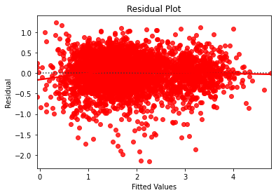

```python
# Check Linearity of variables

# Predicted values
fitted = model3.fittedvalues

# sns.set_style("whitegrid")
sns.residplot(x = fitted, y = residuals, color = "red", lowess = True)

plt.xlabel("Fitted Values")
plt.ylabel("Residual")
plt.title("Residual Plot")

plt.show()
```

Observation:

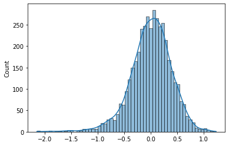

```python
# Check Normality of error terms
# The residuals should be normally distributed

sns.histplot(residuals, kde = True)
```

Observation:

The residuals should be normally distributed

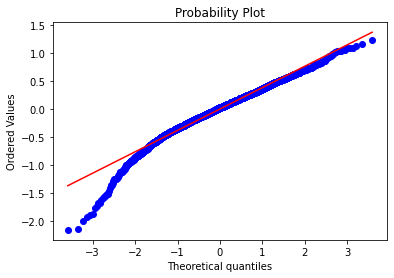

```python
# Q-Q plot of residuals

import pylab

import scipy.stats as stats

stats.probplot(residuals, dist = "norm", plot = pylab)
plt.show()
```

Observation:

Please refer to the coefficient in the OLS summary.

# Decision Tree

```python
from sklearn import tree

from sklearn.tree import DecisionTreeRegressor

# Metrics to evaluate the model
from sklearn import metrics

from sklearn.metrics import mean_squared_error

# For tuning the model
from sklearn.model_selection import GridSearchCV
```

```python
# Create a decision tree regression model

# Set the depth as 5
dt = DecisionTreeRegressor()

# Fit the model to the training data
dt.fit(X_train, y_train)
```

```
DecisionTreeRegressor()
```

### **Hyperparameter Tuning: Decision Tree**

```python
# Define the hyperparameter by using some reasonable starting points

param_grid = {
    'max_depth': np.arange(2,7),
    'min_samples_split': [2,5,10,15,20],
    'min_samples_leaf': [2,5,10,15,20]
}

# Perform grid search cross-validation
gridCV = GridSearchCV(dt, param_grid, cv=5)
gridCV.fit(X_train, y_train)
```

```
GridSearchCV(cv=5, estimator=DecisionTreeRegressor(),
             param_grid={'max_depth': array([2, 3, 4, 5, 6]),
                         'min_samples_leaf': [2, 5, 10, 15, 20],
                         'min_samples_split': [2, 5, 10, 15, 20]})
```

```python
# Get the best model and its hyperparameters
dt_best = gridCV.best_estimator_
params_best = gridCV.best_params_
```

```python
print("Best Hyperparameters are:", params_best)
```

```
Best Hyperparameters are: {'max_depth': 6, 'min_samples_leaf': 5, 'min_samples_split': 5}
```

**Feature Importance**

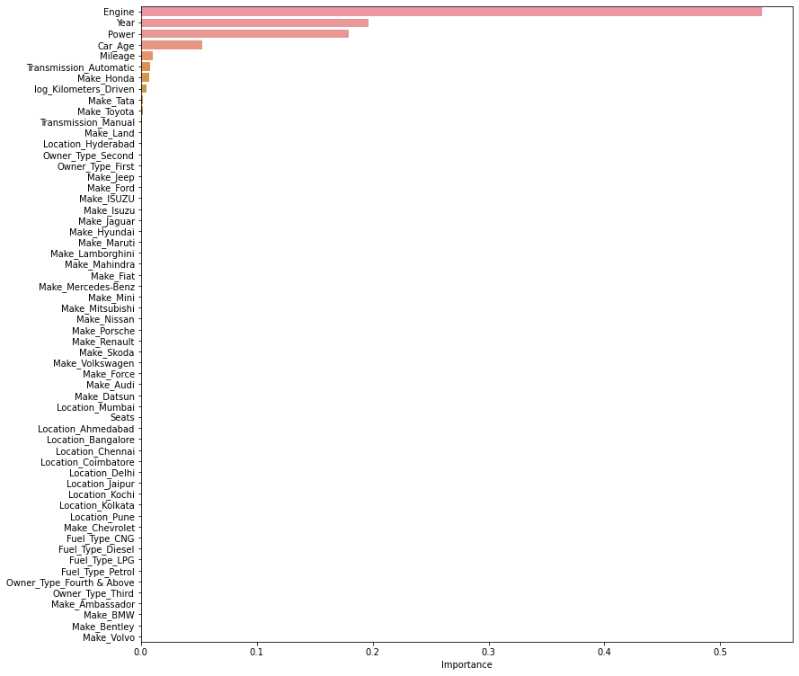

```python
# Analyze feature importance

importances = dt_best.feature_importances_

columns = X.columns

importance_df = pd.DataFrame(importances, index = columns, columns = ['Importance']).sort_values(by = 'Importance', ascending = False)

plt.figure(figsize = (13, 13))

sns.barplot(importance_df.Importance, importance_df.index)
```

```python
# Evaluate the performance

y_pred = dt_best.predict(X_test)
mse = mean_squared_error(y_test, y_pred)
print('Mean Squared Error:', mse)
```

```
Mean Squared Error: 0.10787315339885892
```

Observation:

After hyperparameter tuning and feature importance ploting, we can see 3 major important features.

Mileage and kilometer driven are relatively less important.

# Random Forest

```python
# Import rf
from sklearn.ensemble import RandomForestRegressor

rf = RandomForestRegressor()
```

```python
# fit the rf regressor

rf.fit(X_train, y_train)
```

```
RandomForestRegressor()
```

### **Hyperparameter Tuning: Random Forest**

```python
# Define the hyperparameter
param_grid = {
    'max_depth': [None, 5, 10],
    'min_samples_split': [2, 5, 10],
    'min_samples_leaf': [2,5,10]
}

gridCV2 = GridSearchCV(rf, param_grid, cv=5)
gridCV2.fit(X_train, y_train)

# Get the best model and its hyperparameters
rf_best = gridCV.best_estimator_
params_best = gridCV2.best_params_

print("Best Hyperparameters for rf are:", params_best)
```

```
Best Hyperparameters for rf are: {'max_depth': None, 'min_samples_leaf': 2, 'min_samples_split': 2}
```

**Feature Importance**

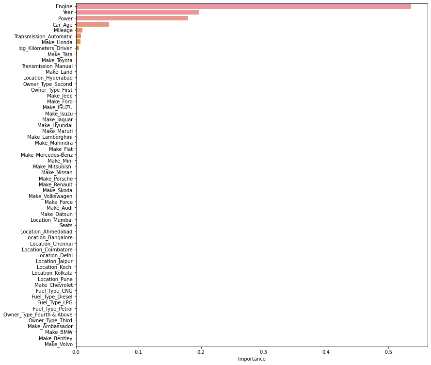

```python
importances = rf_best.feature_importances_

columns = X.columns

importance_df = pd.DataFrame(importances, index = columns, columns = ['Importance']).sort_values(by = 'Importance', ascending = False)

plt.figure(figsize = (13, 13))

sns.barplot(importance_df.Importance, importance_df.index)
```

```python
# Evaluate the performance

y_pred = rf_best.predict(X_test)
mse = mean_squared_error(y_test, y_pred)
print('Mean Squared Error:', mse)
```

```
Mean Squared Error: 0.10787315339885892
```

Observation:

## **Conclusions and Recommendations**

**2. Refined insights:**

- What are the most meaningful insights relevant to the problem?
- My answer: Different regression models fit different problems. It's worth trying different models to find the best one.

**3. Proposal for the final solution design:**